```python
import pandas as pd
import tweepy
import json
import requests
import os
import numpy as np
import matplotlib.pyplot as plt
import seaborn as sb

%matplotlib inline
```

# Gathering:

### WeRateDogs Twitter Archive:

```python
archive = pd.read_csv('twitter-archive-enhanced.csv'); archive.head(1)
```

|  | tweet_id | in_reply_to_status_id | in_reply_to_user_id | timestamp | source | text | retweeted_status_id | retweeted_status_user_id | retweeted_status_timestamp | expanded_urls | rating_numerator | rating_denominator | name | doggo | floofer | pupper | puppo |
| --- | --- | --- | --- | --- | --- | --- | --- | --- | --- | --- | --- | --- | --- | --- | --- | --- | --- |
| 0 | 892420643555336193 | NaN | NaN | 2017-08-01 16:23:56 +0000 | <a href="http://twitter.com/download/iphone" r... | This is Phineas. He's a mystical boy. Only eve... | NaN | NaN | NaN | https://twitter.com/dog_rates/status/892420643... | 13 | 10 | Phineas | None | None | None | None |

### Tweet Image Predictions:

```python
folder_name = 'tweet_image_predictions'

if not os.path.exists(folder_name):
    os.makedirs(folder_name)

url = 'https://d17h27t6h515a5.cloudfront.net/topher/2017/August/599fd2ad_image-predictions/image-predictions.tsv'

response = requests.get(url)
```

```python
with open(os.path.join(folder_name, url.split('/')[-1]), mode = 'wb') as file:
    file.write(response.content)
```

```python
image_preds = pd.read_csv('./tweet_image_predictions/image-predictions.tsv', sep = '\t'); image_preds.head()
```

|  | tweet_id | jpg_url | img_num | p1 | p1_conf | p1_dog | p2 | p2_conf | p2_dog | p3 | p3_conf | p3_dog |
| --- | --- | --- | --- | --- | --- | --- | --- | --- | --- | --- | --- | --- |
| 0 | 666020888022790149 | https://pbs.twimg.com/media/CT4udn0WwAA0aMy.jpg | 1 | Welsh_springer_spaniel | 0.465074 | True | collie | 0.156665 | True | Shetland_sheepdog | 0.061428 | True |
| 1 | 666029285002620928 | https://pbs.twimg.com/media/CT42GRgUYAA5iDo.jpg | 1 | redbone | 0.506826 | True | miniature_pinscher | 0.074192 | True | Rhodesian_ridgeback | 0.072010 | True |
| 2 | 666033412701032449 | https://pbs.twimg.com/media/CT4521TWwAEvMyu.jpg | 1 | German_shepherd | 0.596461 | True | malinois | 0.138584 | True | bloodhound | 0.116197 | True |
| 3 | 666044226329800704 | https://pbs.twimg.com/media/CT5Dr8HUEAA-lEu.jpg | 1 | Rhodesian_ridgeback | 0.408143 | True | redbone | 0.360687 | True | miniature_pinscher | 0.222752 | True |
| 4 | 666049248165822465 | https://pbs.twimg.com/media/CT5IQmsXIAAKY4A.jpg | 1 | miniature_pinscher | 0.560311 | True | Rottweiler | 0.243682 | True | Doberman | 0.154629 | True |

### Twitter API:

```python
# initialize the credentials of Twitter Developer Account
consumer_key = '#####'
consumer_secret = '#####'
access_token = '#####'
access_secret = '#####'

# authenticate as per tweepy docs
auth = tweepy.OAuthHandler(consumer_key, consumer_secret)
auth.set_access_token(access_token, access_secret)

# create api object
api = tweepy.API(auth, wait_on_rate_limit = True, wait_on_rate_limit_notify = True)
```

```python
# make folder to store the twitter api data
folder_name = 'twitter_api_data'
if not os.path.exists(folder_name):
    os.makedirs(folder_name)

# init counter to keep track of tweets collected and of the failed ids
i=1
failed_ids = []

# open file to write json objects from api
with open('./twitter_api_data/tweet_json_no_indent.txt', 'w') as outfile:
    for _ in archive.tweet_id:

        # try-except block since few tweet IDs in the archive may have been deleted
        try:
            tweet = api.get_status(_, tweet_mode = 'extended')
        except:
            failed_ids.append(_)
            i = i+1
            continue

        # print the number of tweets collected
        print(f'{_} | {i} of {len(archive.tweet_id)}')
        i = i+1

        # dump the json object corresponding to the tweet collected from the api
        json.dump(tweet._json, outfile)
        outfile.write('\n')
```

```
892420643555336193 | 1 of 2356
892177421306343426 | 2 of 2356
891815181378084864 | 3 of 2356
891689557279858688 | 4 of 2356
891327558926688256 | 5 of 2356
891087950875897856 | 6 of 2356
890971913173991426 | 7 of 2356
890729181411237888 | 8 of 2356
890609185150312448 | 9 of 2356
890240255349198849 | 10 of 2356
890006608113172480 | 11 of 2356
889880896479866881 | 12 of 2356
889665388333682689 | 13 of 2356
889638837579907072 | 14 of 2356
889531135344209921 | 15 of 2356
```

[output cut: 866 more lines]

```
Rate limit reached. Sleeping for: 115
```

```
758740312047005698 | 901 of 2356
758474966123810816 | 902 of 2356
758467244762497024 | 903 of 2356
758405701903519748 | 904 of 2356
758355060040593408 | 905 of 2356
758099635764359168 | 906 of 2356
758041019896193024 | 907 of 2356
757741869644341248 | 908 of 2356
757729163776290825 | 909 of 2356
757725642876129280 | 910 of 2356
757611664640446465 | 911 of 2356
757597904299253760 | 912 of 2356
757596066325864448 | 913 of 2356
757400162377592832 | 914 of 2356
757393109802180609 | 915 of 2356
```

[output cut: 883 more lines]

```
Rate limit reached. Sleeping for: 91
```

```
676975532580409345 | 1801 of 2356
676957860086095872 | 1802 of 2356
676949632774234114 | 1803 of 2356
676948236477857792 | 1804 of 2356
676946864479084545 | 1805 of 2356
676942428000112642 | 1806 of 2356
676936541936185344 | 1807 of 2356
676916996760600576 | 1808 of 2356
676897532954456065 | 1809 of 2356
676864501615042560 | 1810 of 2356
676821958043033607 | 1811 of 2356
676819651066732545 | 1812 of 2356
676811746707918848 | 1813 of 2356
676776431406465024 | 1814 of 2356
676617503762681856 | 1815 of 2356
```

[output cut: 541 more lines]

```python
len(failed_ids)
```

```
29
```

```python
#load the json data and store it in a list
data = []
with open('./twitter_api_data/tweet_json_no_indent.txt') as f:
        for line in f:
            data.append(json.loads(line))

df_api = pd.DataFrame(data)
#select columns of interest

columns_of_interest = ['id', 'retweet_count', 'favorite_count']
df_api = df_api[columns_of_interest]
```

## Assessing:

> We have the following dataframes: `archive`, `image_preds`, `df_api`.

### Assessing `archive`

```python
archive.head(3)
```

|  | tweet_id | in_reply_to_status_id | in_reply_to_user_id | timestamp | source | text | retweeted_status_id | retweeted_status_user_id | retweeted_status_timestamp | expanded_urls | rating_numerator | rating_denominator | name | doggo | floofer | pupper | puppo |
| --- | --- | --- | --- | --- | --- | --- | --- | --- | --- | --- | --- | --- | --- | --- | --- | --- | --- |
| 0 | 892420643555336193 | NaN | NaN | 2017-08-01 16:23:56 +0000 | <a href="http://twitter.com/download/iphone" r... | This is Phineas. He's a mystical boy. Only eve... | NaN | NaN | NaN | https://twitter.com/dog_rates/status/892420643... | 13 | 10 | Phineas | None | None | None | None |
| 1 | 892177421306343426 | NaN | NaN | 2017-08-01 00:17:27 +0000 | <a href="http://twitter.com/download/iphone" r... | This is Tilly. She's just checking pup on you.... | NaN | NaN | NaN | https://twitter.com/dog_rates/status/892177421... | 13 | 10 | Tilly | None | None | None | None |
| 2 | 891815181378084864 | NaN | NaN | 2017-07-31 00:18:03 +0000 | <a href="http://twitter.com/download/iphone" r... | This is Archie. He is a rare Norwegian Pouncin... | NaN | NaN | NaN | https://twitter.com/dog_rates/status/891815181... | 12 | 10 | Archie | None | None | None | None |

```python
archive.info()
```

```
<class 'pandas.core.frame.DataFrame'>
RangeIndex: 2356 entries, 0 to 2355
Data columns (total 17 columns):
tweet_id                      2356 non-null int64
in_reply_to_status_id         78 non-null float64
in_reply_to_user_id           78 non-null float64
timestamp                     2356 non-null object
source                        2356 non-null object
text                          2356 non-null object
retweeted_status_id           181 non-null float64
retweeted_status_user_id      181 non-null float64
retweeted_status_timestamp    181 non-null object
expanded_urls                 2297 non-null object
rating_numerator              2356 non-null int64
rating_denominator            2356 non-null int64
name                          2356 non-null object
doggo                         2356 non-null object
floofer                       2356 non-null object
pupper                        2356 non-null object
puppo                         2356 non-null object
dtypes: float64(4), int64(3), object(10)
memory usage: 313.0+ KB
```

```python
archive.duplicated().any()
```

```
False
```

```python
archive[archive.retweeted_status_id.notnull()]
```

|  | tweet_id | in_reply_to_status_id | in_reply_to_user_id | timestamp | source | text | retweeted_status_id | retweeted_status_user_id | retweeted_status_timestamp | expanded_urls | rating_numerator | rating_denominator | name | doggo | floofer | pupper | puppo |
| --- | --- | --- | --- | --- | --- | --- | --- | --- | --- | --- | --- | --- | --- | --- | --- | --- | --- |
| 19 | 888202515573088257 | NaN | NaN | 2017-07-21 01:02:36 +0000 | <a href="http://twitter.com/download/iphone" r... | RT @dog_rates: This is Canela. She attempted s... | 8.874740e+17 | 4.196984e+09 | 2017-07-19 00:47:34 +0000 | https://twitter.com/dog_rates/status/887473957... | 13 | 10 | Canela | None | None | None | None |
| 32 | 886054160059072513 | NaN | NaN | 2017-07-15 02:45:48 +0000 | <a href="http://twitter.com/download/iphone" r... | RT @Athletics: 12/10 #BATP https://t.co/WxwJmv... | 8.860537e+17 | 1.960740e+07 | 2017-07-15 02:44:07 +0000 | https://twitter.com/dog_rates/status/886053434... | 12 | 10 | None | None | None | None | None |
| 36 | 885311592912609280 | NaN | NaN | 2017-07-13 01:35:06 +0000 | <a href="http://twitter.com/download/iphone" r... | RT @dog_rates: This is Lilly. She just paralle... | 8.305833e+17 | 4.196984e+09 | 2017-02-12 01:04:29 +0000 | https://twitter.com/dog_rates/status/830583320... | 13 | 10 | Lilly | None | None | None | None |
| 68 | 879130579576475649 | NaN | NaN | 2017-06-26 00:13:58 +0000 | <a href="http://twitter.com/download/iphone" r... | RT @dog_rates: This is Emmy. She was adopted t... | 8.780576e+17 | 4.196984e+09 | 2017-06-23 01:10:23 +0000 | https://twitter.com/dog_rates/status/878057613... | 14 | 10 | Emmy | None | None | None | None |
| 73 | 878404777348136964 | NaN | NaN | 2017-06-24 00:09:53 +0000 | <a href="http://twitter.com/download/iphone" r... | RT @dog_rates: Meet Shadow. In an attempt to r... | 8.782815e+17 | 4.196984e+09 | 2017-06-23 16:00:04 +0000 | https://www.gofundme.com/3yd6y1c,https://twitt... | 13 | 10 | Shadow | None | None | None | None |
| 74 | 878316110768087041 | NaN | NaN | 2017-06-23 18:17:33 +0000 | <a href="http://twitter.com/download/iphone" r... | RT @dog_rates: Meet Terrance. He's being yelle... | 6.690004e+17 | 4.196984e+09 | 2015-11-24 03:51:38 +0000 | https://twitter.com/dog_rates/status/669000397... | 11 | 10 | Terrance | None | None | None | None |
| 78 | 877611172832227328 | NaN | NaN | 2017-06-21 19:36:23 +0000 | <a href="http://twitter.com/download/iphone" r... | RT @rachel2195: @dog_rates the boyfriend and h... | 8.768508e+17 | 5.128045e+08 | 2017-06-19 17:14:49 +0000 | https://twitter.com/rachel2195/status/87685077... | 14 | 10 | None | None | None | pupper | None |
| 91 | 874434818259525634 | NaN | NaN | 2017-06-13 01:14:41 +0000 | <a href="http://twitter.com/download/iphone" r... | RT @dog_rates: This is Coco. At first I though... | 8.663350e+17 | 4.196984e+09 | 2017-05-21 16:48:45 +0000 | https://twitter.com/dog_rates/status/866334964... | 12 | 10 | Coco | None | None | None | None |
| 95 | 873697596434513921 | NaN | NaN | 2017-06-11 00:25:14 +0000 | <a href="http://twitter.com/download/iphone" r... | RT @dog_rates: This is Walter. He won't start ... | 8.688804e+17 | 4.196984e+09 | 2017-05-28 17:23:24 +0000 | https://twitter.com/dog_rates/status/868880397... | 14 | 10 | Walter | None | None | None | None |
| 97 | 873337748698140672 | NaN | NaN | 2017-06-10 00:35:19 +0000 | <a href="http://twitter.com/download/iphone" r... | RT @dog_rates: This is Sierra. She's one preci... | 8.732138e+17 | 4.196984e+09 | 2017-06-09 16:22:42 +0000 | https://www.gofundme.com/help-my-baby-sierra-g... | 12 | 10 | Sierra | None | None | pupper | None |
| 101 | 872668790621863937 | NaN | NaN | 2017-06-08 04:17:07 +0000 | <a href="http://twitter.com/download/iphone" r... | RT @loganamnosis: Penelope here is doing me qu... | 8.726576e+17 | 1.547674e+08 | 2017-06-08 03:32:35 +0000 | https://twitter.com/loganamnosis/status/872657... | 14 | 10 | None | None | None | None | None |
| 109 | 871166179821445120 | NaN | NaN | 2017-06-04 00:46:17 +0000 | <a href="http://twitter.com/download/iphone" r... | RT @dog_rates: This is Dawn. She's just checki... | 8.410770e+17 | 4.196984e+09 | 2017-03-13 00:02:39 +0000 | https://twitter.com/dog_rates/status/841077006... | 12 | 10 | Dawn | None | None | None | None |
| 118 | 869988702071779329 | NaN | NaN | 2017-05-31 18:47:24 +0000 | <a href="http://twitter.com/download/iphone" r... | RT @dog_rates: We only rate dogs. This is quit... | 8.591970e+17 | 4.196984e+09 | 2017-05-02 00:04:57 +0000 | https://twitter.com/dog_rates/status/859196978... | 12 | 10 | quite | None | None | None | None |
| 124 | 868639477480148993 | NaN | NaN | 2017-05-28 01:26:04 +0000 | <a href="http://twitter.com/download/iphone" r... | RT @dog_rates: Say hello to Cooper. His expres... | 8.685523e+17 | 4.196984e+09 | 2017-05-27 19:39:34 +0000 | https://www.gofundme.com/3ti3nps,https://twitt... | 12 | 10 | Cooper | None | None | None | None |
| 130 | 867072653475098625 | NaN | NaN | 2017-05-23 17:40:04 +0000 | <a href="http://twitter.com/download/iphone" r... | RT @rachaeleasler: these @dog_rates hats are 1... | 8.650134e+17 | 7.874618e+17 | 2017-05-18 01:17:25 +0000 | https://twitter.com/rachaeleasler/status/86501... | 13 | 10 | None | None | None | None | None |
| 132 | 866816280283807744 | NaN | NaN | 2017-05-23 00:41:20 +0000 | <a href="http://twitter.com/download/iphone" r... | RT @dog_rates: This is Jamesy. He gives a kiss... | 8.664507e+17 | 4.196984e+09 | 2017-05-22 00:28:40 +0000 | https://twitter.com/dog_rates/status/866450705... | 13 | 10 | Jamesy | None | None | pupper | None |
| 137 | 866094527597207552 | NaN | NaN | 2017-05-21 00:53:21 +0000 | <a href="http://twitter.com/download/iphone" r... | RT @dog_rates: Here's a pupper before and afte... | 8.378202e+17 | 4.196984e+09 | 2017-03-04 00:21:08 +0000 | https://twitter.com/dog_rates/status/837820167... | 12 | 10 | None | None | None | pupper | None |
| 146 | 863471782782697472 | NaN | NaN | 2017-05-13 19:11:30 +0000 | <a href="http://twitter.com/download/iphone" r... | RT @dog_rates: Say hello to Quinn. She's quite... | 8.630625e+17 | 4.196984e+09 | 2017-05-12 16:05:02 +0000 | https://www.gofundme.com/helpquinny,https://tw... | 13 | 10 | Quinn | None | None | None | None |
| 155 | 861769973181624320 | NaN | NaN | 2017-05-09 02:29:07 +0000 | <a href="http://twitter.com/download/iphone" r... | RT @dog_rates: "Good afternoon class today we'... | 8.066291e+17 | 4.196984e+09 | 2016-12-07 22:38:52 +0000 | https://twitter.com/dog_rates/status/806629075... | 13 | 10 | None | None | None | None | None |
| 159 | 860981674716409858 | NaN | NaN | 2017-05-06 22:16:42 +0000 | <a href="http://twitter.com/download/iphone" r... | RT @dog_rates: Meet Lorenzo. He's an avid nift... | 8.605638e+17 | 4.196984e+09 | 2017-05-05 18:36:06 +0000 | https://www.gofundme.com/help-lorenzo-beat-can... | 13 | 10 | Lorenzo | None | None | None | None |
| 160 | 860924035999428608 | NaN | NaN | 2017-05-06 18:27:40 +0000 | <a href="http://twitter.com/download/iphone" r... | RT @tallylott: h*ckin adorable promposal. 13/1... | 8.609145e+17 | 3.638908e+08 | 2017-05-06 17:49:42 +0000 | https://twitter.com/tallylott/status/860914485... | 13 | 10 | None | None | None | None | None |
| 165 | 860177593139703809 | NaN | NaN | 2017-05-04 17:01:34 +0000 | <a href="http://twitter.com/download/iphone" r... | RT @dog_rates: Ohboyohboyohboyohboyohboyohboyo... | 7.616730e+17 | 4.196984e+09 | 2016-08-05 21:19:27 +0000 | https://twitter.com/dog_rates/status/761672994... | 10 | 10 | None | None | None | None | None |
| 171 | 858860390427611136 | NaN | NaN | 2017-05-01 01:47:28 +0000 | <a href="http://twitter.com/download/iphone" r... | RT @dog_rates: Meet Winston. He knows he's a l... | 8.395493e+17 | 4.196984e+09 | 2017-03-08 18:52:12 +0000 | https://twitter.com/dog_rates/status/839549326... | 12 | 10 | Winston | None | None | None | None |
| 180 | 857062103051644929 | NaN | NaN | 2017-04-26 02:41:43 +0000 | <a href="http://twitter.com/download/iphone" r... | RT @AaronChewning: First time wearing my @dog_... | 8.570611e+17 | 5.870972e+07 | 2017-04-26 02:37:47 +0000 | https://twitter.com/AaronChewning/status/85706... | 13 | 10 | None | None | None | None | None |
| 182 | 856602993587888130 | NaN | NaN | 2017-04-24 20:17:23 +0000 | <a href="http://twitter.com/download/iphone" r... | RT @dog_rates: This is Luna. It's her first ti... | 8.447048e+17 | 4.196984e+09 | 2017-03-23 00:18:10 +0000 | https://twitter.com/dog_rates/status/844704788... | 13 | 10 | Luna | None | None | None | None |
| 185 | 856330835276025856 | NaN | NaN | 2017-04-24 02:15:55 +0000 | <a href="http://twitter.com/download/iphone" r... | RT @Jenna_Marbles: @dog_rates Thanks for ratin... | 8.563302e+17 | 6.669901e+07 | 2017-04-24 02:13:14 +0000 | NaN | 14 | 10 | None | None | None | None | None |
| 194 | 855245323840757760 | NaN | NaN | 2017-04-21 02:22:29 +0000 | <a href="http://twitter.com/download/iphone" r... | RT @dog_rates: Meet George. He looks slightly ... | 8.421635e+17 | 4.196984e+09 | 2017-03-16 00:00:07 +0000 | https://twitter.com/dog_rates/status/842163532... | 12 | 10 | George | None | None | None | None |
| 195 | 855138241867124737 | NaN | NaN | 2017-04-20 19:16:59 +0000 | <a href="http://twitter.com/download/iphone" r... | RT @frasercampbell_: oh my... what's that... b... | 8.551225e+17 | 7.475543e+17 | 2017-04-20 18:14:33 +0000 | https://twitter.com/frasercampbell_/status/855... | 14 | 10 | None | None | None | None | None |
| 204 | 852936405516943360 | NaN | NaN | 2017-04-14 17:27:40 +0000 | <a href="http://twitter.com/download/iphone" r... | RT @dog_rates: I usually only share these on F... | 8.316501e+17 | 4.196984e+09 | 2017-02-14 23:43:18 +0000 | http://www.gofundme.com/bluethewhitehusky,http... | 13 | 10 | None | None | None | None | None |
| 211 | 851953902622658560 | NaN | NaN | 2017-04-12 00:23:33 +0000 | <a href="http://twitter.com/download/iphone" r... | RT @dog_rates: This is Astrid. She's a guide d... | 8.293743e+17 | 4.196984e+09 | 2017-02-08 17:00:26 +0000 | https://twitter.com/dog_rates/status/829374341... | 13 | 10 | Astrid | doggo | None | None | None |
| ... | ... | ... | ... | ... | ... | ... | ... | ... | ... | ... | ... | ... | ... | ... | ... | ... | ... |
| 784 | 775096608509886464 | NaN | NaN | 2016-09-11 22:20:06 +0000 | <a href="http://twitter.com/download/iphone" r... | RT @dog_rates: After so many requests, this is... | 7.403732e+17 | 4.196984e+09 | 2016-06-08 02:41:38 +0000 | https://twitter.com/dog_rates/status/740373189... | 9 | 11 | None | None | None | None | None |
| 794 | 773336787167145985 | NaN | NaN | 2016-09-07 01:47:12 +0000 | <a href="http://twitter.com/download/iphone" r... | RT @dog_rates: Meet Fizz. She thinks love is a... | 7.713808e+17 | 4.196984e+09 | 2016-09-01 16:14:48 +0000 | https://twitter.com/dog_rates/status/771380798... | 11 | 10 | Fizz | None | None | None | None |
| 800 | 772615324260794368 | NaN | NaN | 2016-09-05 02:00:22 +0000 | <a href="http://twitter.com/download/iphone" r... | RT @dog_rates: This is Gromit. He's pupset bec... | 7.652221e+17 | 4.196984e+09 | 2016-08-15 16:22:20 +0000 | https://twitter.com/dog_rates/status/765222098... | 10 | 10 | Gromit | None | None | None | None |
| 811 | 771171053431250945 | NaN | NaN | 2016-09-01 02:21:21 +0000 | <a href="http://twitter.com/download/iphone" r... | RT @dog_rates: This is Frankie. He's wearing b... | 6.733201e+17 | 4.196984e+09 | 2015-12-06 01:56:44 +0000 | https://twitter.com/dog_rates/status/673320132... | 11 | 10 | Frankie | None | None | None | None |
| 815 | 771004394259247104 | NaN | NaN | 2016-08-31 15:19:06 +0000 | <a href="http://twitter.com/download/iphone" r... | RT @katieornah: @dog_rates learning a lot at c... | 7.710021e+17 | 1.732729e+09 | 2016-08-31 15:10:07 +0000 | https://twitter.com/katieornah/status/77100213... | 12 | 10 | None | None | None | pupper | None |
| 818 | 770743923962707968 | NaN | NaN | 2016-08-30 22:04:05 +0000 | <a href="http://twitter.com/download/iphone" r... | RT @dog_rates: Here's a doggo blowing bubbles.... | 7.392382e+17 | 4.196984e+09 | 2016-06-04 23:31:25 +0000 | https://twitter.com/dog_rates/status/739238157... | 13 | 10 | None | doggo | None | None | None |
| 822 | 770093767776997377 | NaN | NaN | 2016-08-29 03:00:36 +0000 | <a href="http://twitter.com/download/iphone" r... | RT @dog_rates: This is just downright precious... | 7.410673e+17 | 4.196984e+09 | 2016-06-10 00:39:48 +0000 | https://twitter.com/dog_rates/status/741067306... | 12 | 10 | just | doggo | None | pupper | None |
| 826 | 769335591808995329 | NaN | NaN | 2016-08-27 00:47:53 +0000 | <a href="http://twitter.com/download/iphone" r... | RT @dog_rates: Ever seen a dog pet another dog... | 7.069045e+17 | 4.196984e+09 | 2016-03-07 18:09:06 +0000 | https://vine.co/v/iXQAm5Lrgrh,https://vine.co/... | 13 | 10 | None | None | None | None | None |
| 829 | 768909767477751808 | NaN | NaN | 2016-08-25 20:35:48 +0000 | <a href="http://twitter.com/download/iphone" r... | RT @dog_rates: When it's Janet from accounting... | 7.001438e+17 | 4.196984e+09 | 2016-02-18 02:24:13 +0000 | https://twitter.com/dog_rates/status/700143752... | 10 | 10 | None | None | None | pupper | None |
| 833 | 768554158521745409 | NaN | NaN | 2016-08-24 21:02:45 +0000 | <a href="http://twitter.com/download/iphone" r... | RT @dog_rates: This is Nollie. She's waving at... | 7.399792e+17 | 4.196984e+09 | 2016-06-07 00:36:02 +0000 | https://twitter.com/dog_rates/status/739979191... | 12 | 10 | Nollie | None | None | None | None |
| 841 | 766864461642756096 | NaN | NaN | 2016-08-20 05:08:29 +0000 | <a href="http://twitter.com/download/iphone" r... | RT @dog_rates: We only rate dogs... this is a ... | 7.599238e+17 | 4.196984e+09 | 2016-08-01 01:28:46 +0000 | https://twitter.com/dog_rates/status/759923798... | 10 | 10 | None | None | None | None | None |
| 847 | 766078092750233600 | NaN | NaN | 2016-08-18 01:03:45 +0000 | <a href="http://twitter.com/download/iphone" r... | RT @dog_rates: This is Colby. He's currently r... | 7.258423e+17 | 4.196984e+09 | 2016-04-29 00:21:01 +0000 | https://twitter.com/dog_rates/status/725842289... | 12 | 10 | Colby | None | None | None | None |
| 860 | 763167063695355904 | NaN | NaN | 2016-08-10 00:16:21 +0000 | <a href="http://twitter.com/download/iphone" r... | RT @dog_rates: Meet Eve. She's a raging alcoho... | 6.732953e+17 | 4.196984e+09 | 2015-12-06 00:17:55 +0000 | https://twitter.com/dog_rates/status/673295268... | 8 | 10 | Eve | None | None | pupper | None |
| 868 | 761750502866649088 | NaN | NaN | 2016-08-06 02:27:27 +0000 | <a href="http://twitter.com/download/iphone" r... | RT @dog_rates: "Tristan do not speak to me wit... | 6.853251e+17 | 4.196984e+09 | 2016-01-08 05:00:14 +0000 | https://twitter.com/dog_rates/status/685325112... | 10 | 10 | None | None | None | None | None |
| 872 | 761371037149827077 | NaN | NaN | 2016-08-05 01:19:35 +0000 | <a href="http://twitter.com/download/iphone" r... | RT @dog_rates: Oh. My. God. 13/10 magical af h... | 7.116948e+17 | 4.196984e+09 | 2016-03-20 23:23:54 +0000 | https://twitter.com/dog_rates/status/711694788... | 13 | 10 | None | None | None | None | None |
| 885 | 760153949710192640 | NaN | NaN | 2016-08-01 16:43:19 +0000 | <a href="http://twitter.com/download/iphone" r... | RT @hownottodraw: The story/person behind @dog... | 7.601538e+17 | 1.950368e+08 | 2016-08-01 16:42:51 +0000 | https://weratedogs.com/pages/about-us,https://... | 11 | 10 | None | None | None | None | None |
| 890 | 759566828574212096 | NaN | NaN | 2016-07-31 01:50:18 +0000 | <a href="http://twitter.com/download/iphone" r... | RT @dog_rates: This... is a Tyrannosaurus rex.... | 7.395441e+17 | 4.196984e+09 | 2016-06-05 19:47:03 +0000 | https://twitter.com/dog_rates/status/739544079... | 10 | 10 | None | None | None | None | None |
| 895 | 759159934323924993 | NaN | NaN | 2016-07-29 22:53:27 +0000 | <a href="http://twitter.com/download/iphone" r... | RT @dog_rates: AT DAWN...\nWE RIDE\n\n11/10 ht... | 6.703191e+17 | 4.196984e+09 | 2015-11-27 19:11:49 +0000 | https://twitter.com/dog_rates/status/670319130... | 11 | 10 | None | None | None | None | None |
| 908 | 757729163776290825 | NaN | NaN | 2016-07-26 00:08:05 +0000 | <a href="http://twitter.com/download/iphone" r... | RT @dog_rates: This is Chompsky. He lives up t... | 6.790626e+17 | 4.196984e+09 | 2015-12-21 22:15:18 +0000 | https://twitter.com/dog_rates/status/679062614... | 11 | 10 | Chompsky | None | None | None | None |
| 911 | 757597904299253760 | NaN | NaN | 2016-07-25 15:26:30 +0000 | <a href="http://twitter.com/download/iphone" r... | RT @jon_hill987: @dog_rates There is a cunning... | 7.575971e+17 | 2.804798e+08 | 2016-07-25 15:23:28 +0000 | https://twitter.com/jon_hill987/status/7575971... | 11 | 10 | None | None | None | pupper | None |
| 926 | 754874841593970688 | NaN | NaN | 2016-07-18 03:06:01 +0000 | <a href="http://twitter.com/download/iphone" r... | RT @dog_rates: This is Rubio. He has too much ... | 6.791584e+17 | 4.196984e+09 | 2015-12-22 04:35:49 +0000 | https://twitter.com/dog_rates/status/679158373... | 11 | 10 | Rubio | None | None | None | None |
| 937 | 753298634498793472 | NaN | NaN | 2016-07-13 18:42:44 +0000 | <a href="http://twitter.com/download/iphone" r... | RT @dog_rates: This is Carly. She's actually 2... | 6.815232e+17 | 4.196984e+09 | 2015-12-28 17:12:42 +0000 | https://twitter.com/dog_rates/status/681523177... | 12 | 10 | Carly | None | None | None | None |
| 943 | 752701944171524096 | NaN | NaN | 2016-07-12 03:11:42 +0000 | <a href="http://twitter.com/download/iphone" r... | RT @dog_rates: HEY PUP WHAT'S THE PART OF THE ... | 6.835159e+17 | 4.196984e+09 | 2016-01-03 05:11:12 +0000 | https://vine.co/v/ibvnzrauFuV,https://vine.co/... | 11 | 10 | None | None | None | None | None |
| 949 | 752309394570878976 | NaN | NaN | 2016-07-11 01:11:51 +0000 | <a href="http://twitter.com/download/iphone" r... | RT @dog_rates: Everyone needs to watch this. 1... | 6.753544e+17 | 4.196984e+09 | 2015-12-11 16:40:19 +0000 | https://twitter.com/dog_rates/status/675354435... | 13 | 10 | None | None | None | None | None |
| 1012 | 747242308580548608 | NaN | NaN | 2016-06-27 01:37:04 +0000 | <a href="http://twitter.com/download/iphone" r... | RT @dog_rates: This pupper killed this great w... | 7.047611e+17 | 4.196984e+09 | 2016-03-01 20:11:59 +0000 | https://twitter.com/dog_rates/status/704761120... | 13 | 10 | None | None | None | pupper | None |
| 1023 | 746521445350707200 | NaN | NaN | 2016-06-25 01:52:36 +0000 | <a href="http://twitter.com/download/iphone" r... | RT @dog_rates: This is Shaggy. He knows exactl... | 6.678667e+17 | 4.196984e+09 | 2015-11-21 00:46:50 +0000 | https://twitter.com/dog_rates/status/667866724... | 10 | 10 | Shaggy | None | None | None | None |
| 1043 | 743835915802583040 | NaN | NaN | 2016-06-17 16:01:16 +0000 | <a href="http://twitter.com/download/iphone" r... | RT @dog_rates: Extremely intelligent dog here.... | 6.671383e+17 | 4.196984e+09 | 2015-11-19 00:32:12 +0000 | https://twitter.com/dog_rates/status/667138269... | 10 | 10 | None | None | None | None | None |
| 1242 | 711998809858043904 | NaN | NaN | 2016-03-21 19:31:59 +0000 | <a href="http://twitter.com/download/iphone" r... | RT @twitter: @dog_rates Awesome Tweet! 12/10. ... | 7.119983e+17 | 7.832140e+05 | 2016-03-21 19:29:52 +0000 | https://twitter.com/twitter/status/71199827977... | 12 | 10 | None | None | None | None | None |
| 2259 | 667550904950915073 | NaN | NaN | 2015-11-20 03:51:52 +0000 | <a href="http://twitter.com" rel="nofollow">Tw... | RT @dogratingrating: Exceptional talent. Origi... | 6.675487e+17 | 4.296832e+09 | 2015-11-20 03:43:06 +0000 | https://twitter.com/dogratingrating/status/667... | 12 | 10 | None | None | None | None | None |
| 2260 | 667550882905632768 | NaN | NaN | 2015-11-20 03:51:47 +0000 | <a href="http://twitter.com" rel="nofollow">Tw... | RT @dogratingrating: Unoriginal idea. Blatant ... | 6.675484e+17 | 4.296832e+09 | 2015-11-20 03:41:59 +0000 | https://twitter.com/dogratingrating/status/667... | 5 | 10 | None | None | None | None | None |

181 rows × 17 columns

```python
archive.name.unique()
```

```
array(['Phineas', 'Tilly', 'Archie', 'Darla', 'Franklin', 'None', 'Jax',
       'Zoey', 'Cassie', 'Koda', 'Bruno', 'Ted', 'Stuart', 'Oliver',
       'Jim', 'Zeke', 'Ralphus', 'Canela', 'Gerald', 'Jeffrey', 'such',
       'Maya', 'Mingus', 'Derek', 'Roscoe', 'Waffles', 'Jimbo', 'Maisey',
       'Lilly', 'Earl', 'Lola', 'Kevin', 'Yogi', 'Noah', 'Bella',
       'Grizzwald', 'Rusty', 'Gus', 'Stanley', 'Alfy', 'Koko', 'Rey',
       'Gary', 'a', 'Elliot', 'Louis', 'Jesse', 'Romeo', 'Bailey',
       'Duddles', 'Jack', 'Emmy', 'Steven', 'Beau', 'Snoopy', 'Shadow',
       'Terrance', 'Aja', 'Penny', 'Dante', 'Nelly', 'Ginger', 'Benedict',
       'Venti', 'Goose', 'Nugget', 'Cash', 'Coco', 'Jed', 'Sebastian',
       'Walter', 'Sierra', 'Monkey', 'Harry', 'Kody', 'Lassie', 'Rover',
       'Napolean', 'Dawn', 'Boomer', 'Cody', 'Rumble', 'Clifford',
       'quite', 'Dewey', 'Scout', 'Gizmo', 'Cooper', 'Harold', 'Shikha',
       'Jamesy', 'Lili', 'Sammy', 'Meatball', 'Paisley', 'Albus',
       'Neptune', 'Quinn', 'Belle', 'Zooey', 'Dave', 'Jersey', 'Hobbes',
       'Burt', 'Lorenzo', 'Carl', 'Jordy', 'Milky', 'Trooper', 'Winston',
       'Sophie', 'Wyatt', 'Rosie', 'Thor', 'Oscar', 'Luna', 'Callie',
       'Cermet', 'George', 'Marlee', 'Arya', 'Einstein', 'Alice',
       'Rumpole', 'Benny', 'Aspen', 'Jarod', 'Wiggles', 'General',
       'Sailor', 'Astrid', 'Iggy', 'Snoop', 'Kyle', 'Leo', 'Riley',
       'Gidget', 'Noosh', 'Odin', 'Jerry', 'Charlie', 'Georgie', 'Rontu',
       'Cannon', 'Furzey', 'Daisy', 'Tuck', 'Barney', 'Vixen', 'Jarvis',
       'Mimosa', 'Pickles', 'Bungalo', 'Brady', 'Margo', 'Sadie', 'Hank',
       'Tycho', 'Stephan', 'Indie', 'Winnie', 'Bentley', 'Ken', 'Max',
       'Maddie', 'Pipsy', 'Monty', 'Sojourner', 'Odie', 'Arlo', 'Sunny',
       'Vincent', 'Lucy', 'Clark', 'Mookie', 'Meera', 'Buddy', 'Ava',
       'Rory', 'Eli', 'Ash', 'Tucker', 'Tobi', 'Chester', 'Wilson',
       'Sunshine', 'Lipton', 'Gabby', 'Bronte', 'Poppy', 'Rhino',
       'Willow', 'not', 'Orion', 'Eevee', 'Smiley', 'Logan', 'Moreton',
       'Klein', 'Miguel', 'Emanuel', 'Kuyu', 'Dutch', 'Pete', 'Scooter',
       'Reggie', 'Kyro', 'Samson', 'Loki', 'Mia', 'Malcolm', 'Dexter',
       'Alfie', 'Fiona', 'one', 'Mutt', 'Bear', 'Doobert', 'Beebop',
       'Alexander', 'Sailer', 'Brutus', 'Kona', 'Boots', 'Ralphie',
       'Phil', 'Cupid', 'Pawnd', 'Pilot', 'Ike', 'Mo', 'Toby', 'Sweet',
       'Pablo', 'Nala', 'Balto', 'Crawford', 'Gabe', 'Mattie', 'Jimison',
       'Hercules', 'Duchess', 'Harlso', 'Sampson', 'Sundance', 'Luca',
       'Flash', 'Finn', 'Peaches', 'Howie', 'Jazzy', 'Anna', 'Bo',
       'Seamus', 'Wafer', 'Chelsea', 'Tom', 'Moose', 'Florence', 'Autumn',
       'Dido', 'Eugene', 'Herschel', 'Strudel', 'Tebow', 'Chloe', 'Betty',
       'Timber', 'Binky', 'Dudley', 'Comet', 'Larry', 'Levi', 'Akumi',
```

[output cut: 88 more lines]

```
       'Anthony', 'Holly', 'Jett', 'Amy', 'Sage', 'Andy', 'Mason',
       'Trigger', 'Antony', 'Creg', 'Traviss', 'Gin', 'Jeffrie', 'Danny',
       'Ester', 'Pluto', 'Bloo', 'Edd', 'Willy', 'Herb', 'Damon',
       'Peanut', 'Nigel', 'Butters', 'Sandra', 'Fabio', 'Randall', 'Liam',
       'Tommy', 'Ben', 'Raphael', 'Julio', 'Andru', 'Kloey', 'Shawwn',
       'Skye', 'Kollin', 'Ronduh', 'Billl', 'Saydee', 'Dug', 'Tessa',
       'Sully', 'Kirk', 'Ralf', 'Clarq', 'Jaspers', 'Samsom', 'Harrison',
       'Chaz', 'Jeremy', 'Jaycob', 'Lambeau', 'Ruffles', 'Amélie', 'Bobb',
       'Banditt', 'Kevon', 'Winifred', 'Hanz', 'Churlie', 'Zeek',
       'Timofy', 'Maks', 'Jomathan', 'Kallie', 'Marvin', 'Spark',
       'Gòrdón', 'Jo', 'DayZ', 'Jareld', 'Torque', 'Ron', 'Skittles',
       'Cleopatricia', 'Erik', 'Stu', 'Tedrick', 'Filup', 'Kial',
       'Naphaniel', 'Dook', 'Hall', 'Philippe', 'Biden', 'Fwed',
       'Genevieve', 'Joshwa', 'Bradlay', 'Clybe', 'Keet', 'Carll',
       'Jockson', 'Josep', 'Lugan', 'Christoper'], dtype=object)
```

```python
archive.source.unique()
```

```
array(['<a href="http://twitter.com/download/iphone" rel="nofollow">Twitter for iPhone</a>',
       '<a href="http://twitter.com" rel="nofollow">Twitter Web Client</a>',
       '<a href="http://vine.co" rel="nofollow">Vine - Make a Scene</a>',
       '<a href="https://about.twitter.com/products/tweetdeck" rel="nofollow">TweetDeck</a>'],
      dtype=object)
```

#### Data Quality issues:

- There are 181 retweets as evident from the column `retweet_status_id`.
- `timestamp` column is type `object`.
- `tweet_id` column is type `int64`.
- Some of the tweets with `name` as: **[the, old, actually, just, an, mad, one, not, such, a, None]** are not relating to dogs.
- The `source` column has unnecessary HTML tags.

#### Data Tidiness issues:

- The columns names `doggo`, `floofer`, `pupper`, `puppo` are not variables. They are possible values.

### Assessing: `image_preds`

```python
image_preds.head(3)
```

|  | tweet_id | jpg_url | img_num | p1 | p1_conf | p1_dog | p2 | p2_conf | p2_dog | p3 | p3_conf | p3_dog |
| --- | --- | --- | --- | --- | --- | --- | --- | --- | --- | --- | --- | --- |
| 0 | 666020888022790149 | https://pbs.twimg.com/media/CT4udn0WwAA0aMy.jpg | 1 | Welsh_springer_spaniel | 0.465074 | True | collie | 0.156665 | True | Shetland_sheepdog | 0.061428 | True |
| 1 | 666029285002620928 | https://pbs.twimg.com/media/CT42GRgUYAA5iDo.jpg | 1 | redbone | 0.506826 | True | miniature_pinscher | 0.074192 | True | Rhodesian_ridgeback | 0.072010 | True |
| 2 | 666033412701032449 | https://pbs.twimg.com/media/CT4521TWwAEvMyu.jpg | 1 | German_shepherd | 0.596461 | True | malinois | 0.138584 | True | bloodhound | 0.116197 | True |

```python
image_preds.info()
```

```
<class 'pandas.core.frame.DataFrame'>
RangeIndex: 2075 entries, 0 to 2074
Data columns (total 12 columns):
tweet_id    2075 non-null int64
jpg_url     2075 non-null object
img_num     2075 non-null int64
p1          2075 non-null object
p1_conf     2075 non-null float64
p1_dog      2075 non-null bool
p2          2075 non-null object
p2_conf     2075 non-null float64
p2_dog      2075 non-null bool
p3          2075 non-null object
p3_conf     2075 non-null float64
p3_dog      2075 non-null bool
dtypes: bool(3), float64(3), int64(2), object(4)
memory usage: 152.1+ KB
```

```python
image_preds.duplicated().any()
```

```
False
```

```python
image_preds.p1_dog.value_counts()
```

```
True     1532
False     543
Name: p1_dog, dtype: int64
```

#### Data Quality issues:

- `tweet_id` is data type `int64`.
- The above 543 rows have `p1_dog` value as False. They're not dogs.

### Assessing: df_api

```python
df_api.head(3)
```

|  | id | retweet_count | favorite_count |
| --- | --- | --- | --- |
| 0 | 892420643555336193 | 8141 | 37445 |
| 1 | 892177421306343426 | 6031 | 32180 |
| 2 | 891815181378084864 | 3993 | 24265 |

```python
df_api.info()
```

```
<class 'pandas.core.frame.DataFrame'>
RangeIndex: 2335 entries, 0 to 2334
Data columns (total 3 columns):
id                2335 non-null int64
retweet_count     2335 non-null int64
favorite_count    2335 non-null int64
dtypes: int64(3)
memory usage: 54.8 KB
```

```python
df_api.duplicated().any()
```

```
False
```

#### Data Tidiness Issues:

- `df_api` should not be an independent table. It should be joined with `archive`.

# Cleaning:

### Twitter `archive`:

#### Data Quality issues:

- Drop the 181 retweets as evident from the column `retweet_status_id`.
- Convert `timestamp` column from `object` to `datetime`.
- Convert `tweet_id` column from `int64` to `object`.
- Drop the tweets with `name` as **[the, old, actually, just, an, mad, one, not, such, a, None]** since they are not relating to dogs.
- Remove the HTML tags from the entries of the `source` column using `regex`.

#### Data Tidiness issues:

- `melt` the columns `doggo`, `floofer`, `pupper`, `puppo` as they are not variables names but possible values.

```python
archive.head(2)
```

|  | tweet_id | in_reply_to_status_id | in_reply_to_user_id | timestamp | source | text | retweeted_status_id | retweeted_status_user_id | retweeted_status_timestamp | expanded_urls | rating_numerator | rating_denominator | name | doggo | floofer | pupper | puppo |
| --- | --- | --- | --- | --- | --- | --- | --- | --- | --- | --- | --- | --- | --- | --- | --- | --- | --- |
| 0 | 892420643555336193 | NaN | NaN | 2017-08-01 16:23:56 +0000 | <a href="http://twitter.com/download/iphone" r... | This is Phineas. He's a mystical boy. Only eve... | NaN | NaN | NaN | https://twitter.com/dog_rates/status/892420643... | 13 | 10 | Phineas | None | None | None | None |
| 1 | 892177421306343426 | NaN | NaN | 2017-08-01 00:17:27 +0000 | <a href="http://twitter.com/download/iphone" r... | This is Tilly. She's just checking pup on you.... | NaN | NaN | NaN | https://twitter.com/dog_rates/status/892177421... | 13 | 10 | Tilly | None | None | None | None |

```python
archive_clean = archive[archive.retweeted_status_id.isnull()]
```

```python
archive_clean.timestamp = pd.to_datetime(archive.timestamp)
```

```python
archive_clean.tweet_id = archive_clean.tweet_id.astype(str)
```

```python
weird_names = ['the', 'old', 'actually', 'just', 'an', 'mad', 'one', 'not', 'such', 'a', 'None', 'Nan']

archive_clean.name = archive_clean.name[~archive_clean.name.isin(weird_names)]
```

```python
archive_clean.source.unique()
```

```
array(['<a href="http://twitter.com/download/iphone" rel="nofollow">Twitter for iPhone</a>',
       '<a href="http://twitter.com" rel="nofollow">Twitter Web Client</a>',
       '<a href="http://vine.co" rel="nofollow">Vine - Make a Scene</a>',
       '<a href="https://about.twitter.com/products/tweetdeck" rel="nofollow">TweetDeck</a>'],
      dtype=object)
```

```python
archive_clean.source = archive_clean.source.str.replace(r'(^<.+".)', '')
archive_clean.source = archive_clean.source.str.replace(r'<.+', '')
```

```python
def replace(x):
    return x.replace('None', '')

archive_clean[['doggo', 'floofer', 'pupper', 'puppo']] = archive_clean[['doggo', 'floofer', 'pupper', 'puppo']].apply(lambda x: replace(x))

archive_clean['dog_stage']= archive_clean['doggo'] + archive_clean['floofer'] + archive_clean['pupper'] + archive_clean['puppo']

archive_clean.dog_stage.value_counts()
```

[output not shown]

```
                1831
pupper           224
doggo             75
puppo             24
doggopupper       10
floofer            9
doggofloofer       1
doggopuppo         1
Name: dog_stage, dtype: int64
```

```python
archive_clean.dog_stage = archive_clean.dog_stage.str.replace('doggopupper', 'doggo, pupper')
archive_clean.dog_stage = archive_clean.dog_stage.str.replace('doggopuppo', 'doggo, puppo')
archive_clean.dog_stage = archive_clean.dog_stage.str.replace('doggofloofer', 'doggo, floofer')

archive_clean.drop(['doggo', 'floofer', 'pupper', 'puppo'], axis = 'columns', inplace = True)
```

```python
archive_clean.dog_stage.value_counts()
```

```
                  1831
pupper             224
doggo               75
puppo               24
doggo, pupper       10
floofer              9
doggo, puppo         1
doggo, floofer       1
Name: dog_stage, dtype: int64
```

```python
archive_clean.head()
```

|  | tweet_id | in_reply_to_status_id | in_reply_to_user_id | timestamp | source | text | retweeted_status_id | retweeted_status_user_id | retweeted_status_timestamp | expanded_urls | rating_numerator | rating_denominator | name | dog_stage |
| --- | --- | --- | --- | --- | --- | --- | --- | --- | --- | --- | --- | --- | --- | --- |
| 0 | 892420643555336193 | NaN | NaN | 2017-08-01 16:23:56+00:00 | Twitter for iPhone | This is Phineas. He's a mystical boy. Only eve... | NaN | NaN | NaN | https://twitter.com/dog_rates/status/892420643... | 13 | 10 | Phineas |  |
| 1 | 892177421306343426 | NaN | NaN | 2017-08-01 00:17:27+00:00 | Twitter for iPhone | This is Tilly. She's just checking pup on you.... | NaN | NaN | NaN | https://twitter.com/dog_rates/status/892177421... | 13 | 10 | Tilly |  |
| 2 | 891815181378084864 | NaN | NaN | 2017-07-31 00:18:03+00:00 | Twitter for iPhone | This is Archie. He is a rare Norwegian Pouncin... | NaN | NaN | NaN | https://twitter.com/dog_rates/status/891815181... | 12 | 10 | Archie |  |
| 3 | 891689557279858688 | NaN | NaN | 2017-07-30 15:58:51+00:00 | Twitter for iPhone | This is Darla. She commenced a snooze mid meal... | NaN | NaN | NaN | https://twitter.com/dog_rates/status/891689557... | 13 | 10 | Darla |  |
| 4 | 891327558926688256 | NaN | NaN | 2017-07-29 16:00:24+00:00 | Twitter for iPhone | This is Franklin. He would like you to stop ca... | NaN | NaN | NaN | https://twitter.com/dog_rates/status/891327558... | 12 | 10 | Franklin |  |

### Cleaning `image_preds`

#### Data Quality issues:

- Convert `tweet_id` to data type `object`.
- Remove the 543 rows that have `p1_dog` value as False. They're not dogs.

```python
image_preds_clean = image_preds.copy()
```

```python
image_preds_clean.head()
```

|  | tweet_id | jpg_url | img_num | p1 | p1_conf | p1_dog | p2 | p2_conf | p2_dog | p3 | p3_conf | p3_dog |
| --- | --- | --- | --- | --- | --- | --- | --- | --- | --- | --- | --- | --- |
| 0 | 666020888022790149 | https://pbs.twimg.com/media/CT4udn0WwAA0aMy.jpg | 1 | Welsh_springer_spaniel | 0.465074 | True | collie | 0.156665 | True | Shetland_sheepdog | 0.061428 | True |
| 1 | 666029285002620928 | https://pbs.twimg.com/media/CT42GRgUYAA5iDo.jpg | 1 | redbone | 0.506826 | True | miniature_pinscher | 0.074192 | True | Rhodesian_ridgeback | 0.072010 | True |
| 2 | 666033412701032449 | https://pbs.twimg.com/media/CT4521TWwAEvMyu.jpg | 1 | German_shepherd | 0.596461 | True | malinois | 0.138584 | True | bloodhound | 0.116197 | True |
| 3 | 666044226329800704 | https://pbs.twimg.com/media/CT5Dr8HUEAA-lEu.jpg | 1 | Rhodesian_ridgeback | 0.408143 | True | redbone | 0.360687 | True | miniature_pinscher | 0.222752 | True |
| 4 | 666049248165822465 | https://pbs.twimg.com/media/CT5IQmsXIAAKY4A.jpg | 1 | miniature_pinscher | 0.560311 | True | Rottweiler | 0.243682 | True | Doberman | 0.154629 | True |

```python
image_preds_clean.tweet_id = image_preds_clean.tweet_id.astype(str);
```

```python
image_preds_clean = image_preds_clean[image_preds_clean.p1_dog != False]
```

## Cleaning `df_api`

#### Data Tidiness Issues:

- Join `df_api` with `archive`.

```python
df_api_clean = df_api.copy()
```

```python
df_api_clean.shape
```

```
(2335, 3)
```

```python
df_api_clean.rename(columns = {'id':'tweet_id'}, inplace = True)
```

```python
df_api_clean.tweet_id = df_api_clean.tweet_id.astype(str)
```

### Merging Dataframes:

```python
df = archive_clean.merge(df_api_clean, on = 'tweet_id', how = 'left')
```

```python
df.columns
```

```
Index(['tweet_id', 'in_reply_to_status_id', 'in_reply_to_user_id', 'timestamp',
       'source', 'text', 'retweeted_status_id', 'retweeted_status_user_id',
       'retweeted_status_timestamp', 'expanded_urls', 'rating_numerator',
       'rating_denominator', 'name', 'dog_stage', 'retweet_count',
       'favorite_count'],
      dtype='object')
```

```python
tweet_info = df[['tweet_id', 'in_reply_to_status_id', 'in_reply_to_user_id', 'timestamp',
       'source', 'text', 'retweeted_status_id', 'retweeted_status_user_id',
       'retweeted_status_timestamp', 'expanded_urls']]

dog_info = df[['tweet_id', 'rating_numerator',
       'rating_denominator', 'name', 'dog_stage', 'retweet_count',
       'favorite_count']]
```

```python
dog_info.head()
```

|  | tweet_id | rating_numerator | rating_denominator | name | dog_stage | retweet_count | favorite_count |
| --- | --- | --- | --- | --- | --- | --- | --- |
| 0 | 892420643555336193 | 13 | 10 | Phineas |  | 8141.0 | 37445.0 |
| 1 | 892177421306343426 | 13 | 10 | Tilly |  | 6031.0 | 32180.0 |
| 2 | 891815181378084864 | 12 | 10 | Archie |  | 3993.0 | 24265.0 |
| 3 | 891689557279858688 | 13 | 10 | Darla |  | 8296.0 | 40744.0 |
| 4 | 891327558926688256 | 12 | 10 | Franklin |  | 8995.0 | 38976.0 |

```python
dog_info = dog_info.merge(image_preds_clean, on='tweet_id', how = 'left')
```

```python
dog_info.dropna(inplace = True)
```

```python
dog_info.reset_index(inplace = True)
dog_info.drop('index', axis = 'columns', inplace = True)
```

#### Final Dataframes: `dog_info`, `tweet_info`

```python
dog_info.head()
```

|  | tweet_id | rating_numerator | rating_denominator | name | dog_stage | retweet_count | favorite_count | jpg_url | img_num | p1 | p1_conf | p1_dog | p2 | p2_conf | p2_dog | p3 | p3_conf | p3_dog |
| --- | --- | --- | --- | --- | --- | --- | --- | --- | --- | --- | --- | --- | --- | --- | --- | --- | --- | --- |
| 0 | 892177421306343426 | 13 | 10 | Tilly |  | 6031.0 | 32180.0 | https://pbs.twimg.com/media/DGGmoV4XsAAUL6n.jpg | 1.0 | Chihuahua | 0.323581 | True | Pekinese | 0.090647 | True | papillon | 0.068957 | True |
| 1 | 891815181378084864 | 12 | 10 | Archie |  | 3993.0 | 24265.0 | https://pbs.twimg.com/media/DGBdLU1WsAANxJ9.jpg | 1.0 | Chihuahua | 0.716012 | True | malamute | 0.078253 | True | kelpie | 0.031379 | True |
| 2 | 891327558926688256 | 12 | 10 | Franklin |  | 8995.0 | 38976.0 | https://pbs.twimg.com/media/DF6hr6BUMAAzZgT.jpg | 2.0 | basset | 0.555712 | True | English_springer | 0.225770 | True | German_short-haired_pointer | 0.175219 | True |
| 3 | 890971913173991426 | 13 | 10 | Jax |  | 1982.0 | 11439.0 | https://pbs.twimg.com/media/DF1eOmZXUAALUcq.jpg | 1.0 | Appenzeller | 0.341703 | True | Border_collie | 0.199287 | True | ice_lolly | 0.193548 | False |
| 4 | 890609185150312448 | 13 | 10 | Zoey |  | 4099.0 | 26949.0 | https://pbs.twimg.com/media/DFwUU__XcAEpyXI.jpg | 1.0 | Irish_terrier | 0.487574 | True | Irish_setter | 0.193054 | True | Chesapeake_Bay_retriever | 0.118184 | True |

```python
tweet_info.head()
```

|  | tweet_id | in_reply_to_status_id | in_reply_to_user_id | timestamp | source | text | retweeted_status_id | retweeted_status_user_id | retweeted_status_timestamp | expanded_urls |
| --- | --- | --- | --- | --- | --- | --- | --- | --- | --- | --- |
| 0 | 892420643555336193 | NaN | NaN | 2017-08-01 16:23:56+00:00 | Twitter for iPhone | This is Phineas. He's a mystical boy. Only eve... | NaN | NaN | NaN | https://twitter.com/dog_rates/status/892420643... |
| 1 | 892177421306343426 | NaN | NaN | 2017-08-01 00:17:27+00:00 | Twitter for iPhone | This is Tilly. She's just checking pup on you.... | NaN | NaN | NaN | https://twitter.com/dog_rates/status/892177421... |
| 2 | 891815181378084864 | NaN | NaN | 2017-07-31 00:18:03+00:00 | Twitter for iPhone | This is Archie. He is a rare Norwegian Pouncin... | NaN | NaN | NaN | https://twitter.com/dog_rates/status/891815181... |
| 3 | 891689557279858688 | NaN | NaN | 2017-07-30 15:58:51+00:00 | Twitter for iPhone | This is Darla. She commenced a snooze mid meal... | NaN | NaN | NaN | https://twitter.com/dog_rates/status/891689557... |
| 4 | 891327558926688256 | NaN | NaN | 2017-07-29 16:00:24+00:00 | Twitter for iPhone | This is Franklin. He would like you to stop ca... | NaN | NaN | NaN | https://twitter.com/dog_rates/status/891327558... |

## Data Visualization

We have the following clean dataframes:

- `dog_info`
- `tweet_info`

### Insight 1:

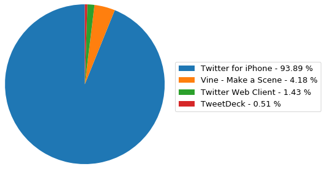

```python
indices = tweet_info.source.value_counts().index
percents = 100 * (tweet_info.source.value_counts().values/tweet_info.source.value_counts().sum())

labels = [f'{i} - {j:1.2f} %' for i,j in zip(indices, percents)]

patches, text = plt.pie(tweet_info.source.value_counts(), radius = 1.5,
       startangle = 90);

plt.legend(patches, labels,  bbox_to_anchor=(+1.15, 0.7), fontsize = 13);
```

> Looks like the most popular medium for tweeting for the WeRateDogs handle is iPhone.

### Insight 2:

```python
temp = dog_info[['dog_stage', 'retweet_count', 'favorite_count', 'rating_numerator']]
```

```python
temp.dog_stage.unique()
```

```
array(['', 'doggo', 'puppo', 'pupper', 'floofer', 'doggo, pupper'],
      dtype=object)
```

```python
# remove the rows with unspecified and ambiguous dog stages
x = temp.dog_stage.unique()[1:-1]

temp = temp.query('dog_stage in @x')
```

```python
temp['dog_stage'] = pd.Categorical(temp.dog_stage, categories = ['pupper', 'puppo','doggo', 'floofer'],
                                  ordered = True)
```

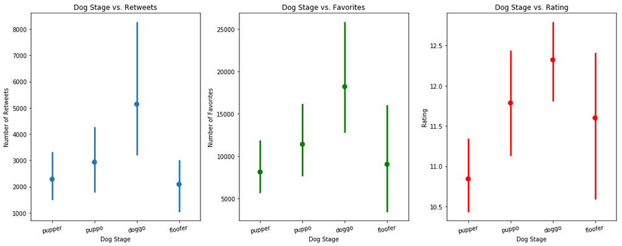

```python
fig = plt.figure(figsize = [15, 6])

plt.subplot(1, 3, 1)
sb.pointplot(data = temp, x = 'dog_stage', y = 'retweet_count', linestyles = '')
plt.xlabel('Dog Stage')
plt.xticks(rotation = 10)
plt.ylabel('Number of Retweets')
plt.title('Dog Stage vs. Retweets')

plt.subplot(1, 3, 2)
sb.pointplot(data = temp, x = 'dog_stage', y = 'favorite_count', linestyles = '', color = 'g')
plt.xlabel('Dog Stage')
plt.xticks(rotation = 10)
plt.ylabel('Number of Favorites');
plt.title('Dog Stage vs. Favorites')

plt.subplot(1, 3, 3)
sb.pointplot(data = temp, x = 'dog_stage', y = 'rating_numerator', linestyles = '', color = 'r')
plt.xlabel('Dog Stage')
plt.xticks(rotation = 10)
plt.ylabel('Rating');
plt.title('Dog Stage vs. Rating')
plt.tight_layout()
```

### Insight 3:

```python
temp1 = dog_info.copy()
```

```python
dog_info.p1.value_counts()[0:20].index
```

```
Index(['golden_retriever', 'Pembroke', 'Labrador_retriever', 'Chihuahua',
       'pug', 'chow', 'toy_poodle', 'Pomeranian', 'Samoyed', 'malamute',
       'French_bulldog', 'Siberian_husky', 'cocker_spaniel',
       'Chesapeake_Bay_retriever', 'miniature_pinscher',
       'Staffordshire_bullterrier', 'Shih-Tzu', 'Cardigan', 'German_shepherd',
       'Shetland_sheepdog'],
      dtype='object')
```

```python
#select first 20 most common breeds
select_breeds = dog_info.p1.value_counts()[0:20].index
temp1 = temp1.query('p1 in @select_breeds')
```

```python
temp1['p1'] = pd.Categorical(temp1.p1,categories = ['golden_retriever', 'Pembroke', 'Labrador_retriever', 'Chihuahua',
       'pug', 'chow', 'toy_poodle', 'Pomeranian', 'Samoyed', 'malamute',
       'French_bulldog', 'Siberian_husky', 'cocker_spaniel',
       'Chesapeake_Bay_retriever', 'miniature_pinscher',
       'Staffordshire_bullterrier', 'Shih-Tzu', 'Cardigan', 'German_shepherd',
       'Shetland_sheepdog'], ordered = True)
```

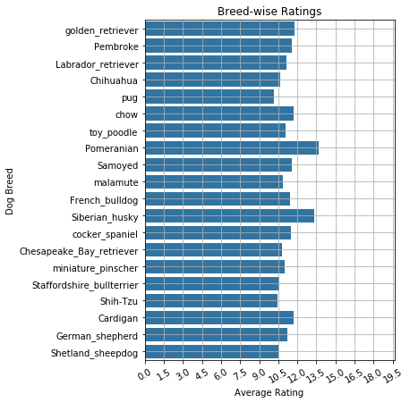

```python
plt.figure(figsize = [5, 7])
sb.barplot(data = temp1, y = 'p1', x = 'rating_numerator', color = sb.color_palette()[0], errwidth = 0)
plt.xticks(np.arange(0, 20, 1.5), rotation = 30)
plt.grid(b = True, which = 'major', linestyle = '-')

plt.title('Breed-wise Ratings')
plt.ylabel('Dog Breed')
plt.xlabel('Average Rating');
```

> The top three most highly rated breeds seem to be:
> - Pomeranian
> - Siberian Huskey
> - Golden Retriever